# Data Science - Technical Assignment

Michelle Plunkett

January 22, 2019

# Import Libraries/Packages

```r
# Load packages
if (!require("pacman")) install.packages("pacman")
pacman::p_load(tidyverse, glmnet)
options(stringsAsFactors = FALSE)
```

# Read Dataset

**Link:** https://www.kaggle.com/uciml/pima-indians-diabetes-database/version/1

```r
# Read in CSV
diabetes <- read_csv("~/Downloads/technical_assignment/diabetes.csv")
# Look at structure
str(diabetes)
```

```
## Classes 'spec_tbl_df', 'tbl_df', 'tbl' and 'data.frame': 768 obs. of  9 variables:
##  $ Pregnancies             : num  6 1 8 1 0 5 3 10 2 8 ...
##  $ Glucose                 : num  148 85 183 89 137 116 78 115 197 125 ...
##  $ BloodPressure           : num  72 66 64 66 40 74 50 0 70 96 ...
##  $ SkinThickness           : num  35 29 0 23 35 0 32 0 45 0 ...
##  $ Insulin                 : num  0 0 0 94 168 0 88 0 543 0 ...
##  $ BMI                     : num  33.6 26.6 23.3 28.1 43.1 25.6 31 35.3 30.5 0 ...
##  $ DiabetesPedigreeFunction: num  0.627 0.351 0.672 0.167 2.288 ...
##  $ Age                     : num  50 31 32 21 33 30 26 29 53 54 ...
##  $ Outcome                 : num  1 0 1 0 1 0 1 0 1 1 ...
##  - attr(*, "spec")=
##   .. cols(
##   ..   Pregnancies = col_double(),
##   ..   Glucose = col_double(),
##   ..   BloodPressure = col_double(),
##   ..   SkinThickness = col_double(),
##   ..   Insulin = col_double(),
##   ..   BMI = col_double(),
##   ..   DiabetesPedigreeFunction = col_double(),
##   ..   Age = col_double(),
##   ..   Outcome = col_double()
##   .. )
```

# Analyze Dataset

*Take a look at some of the rows in the dataset.*

```r
# Look at head of data
head(diabetes)
```

| Pregnancies | Glucose | BloodPressure | SkinThickness | Insulin | BMI | DiabetesPedigreeFunction | Age | Outcome |
| --- | --- | --- | --- | --- | --- | --- | --- | --- |
| 6 | 148 | 72 | 35 | 0 | 33.6 | 0.627 | 50 | 1 |
| 1 | 85 | 66 | 29 | 0 | 26.6 | 0.351 | 31 | 0 |
| 8 | 183 | 64 | 0 | 0 | 23.3 | 0.672 | 32 | 1 |
| 1 | 89 | 66 | 23 | 94 | 28.1 | 0.167 | 21 | 0 |
| 0 | 137 | 40 | 35 | 168 | 43.1 | 2.288 | 33 | 1 |
| 5 | 116 | 74 | 0 | 0 | 25.6 | 0.201 | 30 | 0 |

```r
# Look at summary
summary(diabetes)
```

```
##   Pregnancies        Glucose      BloodPressure    SkinThickness
##  Min.   : 0.000   Min.   :  0.0   Min.   :  0.00   Min.   : 0.00
##  1st Qu.: 1.000   1st Qu.: 99.0   1st Qu.: 62.00   1st Qu.: 0.00
##  Median : 3.000   Median :117.0   Median : 72.00   Median :23.00
##  Mean   : 3.845   Mean   :120.9   Mean   : 69.11   Mean   :20.54
##  3rd Qu.: 6.000   3rd Qu.:140.2   3rd Qu.: 80.00   3rd Qu.:32.00
##  Max.   :17.000   Max.   :199.0   Max.   :122.00   Max.   :99.00
##     Insulin           BMI        DiabetesPedigreeFunction      Age
##  Min.   :  0.0   Min.   : 0.00   Min.   :0.0780           Min.   :21.00
##  1st Qu.:  0.0   1st Qu.:27.30   1st Qu.:0.2437           1st Qu.:24.00
##  Median : 30.5   Median :32.00   Median :0.3725           Median :29.00
##  Mean   : 79.8   Mean   :31.99   Mean   :0.4719           Mean   :33.24
##  3rd Qu.:127.2   3rd Qu.:36.60   3rd Qu.:0.6262           3rd Qu.:41.00
##  Max.   :846.0   Max.   :67.10   Max.   :2.4200           Max.   :81.00
##     Outcome
##  Min.   :0.000
##  1st Qu.:0.000
##  Median :0.000
##  Mean   :0.349
##  3rd Qu.:1.000
##  Max.   :1.000
```

I noticed in the above summary that `Glucose`, `BloodPressure`, `SkinThickness`, `Insulin`, and `BMI` all have a minimum value of 0. I am going to create models using a complete dataset (using only samples where there is a measurement >0 for all variables except `Prenancies`) and therefore I will remove the relevant rows where these variables = 0.

```r
# Review counts of rows where data = 0
# (except for Pregnancies, DiabetesPedigreeFunction, & Outcome)
sapply(diabetes[,2:7], function(x) sum(x==0))
```

```
##                  Glucose            BloodPressure            SkinThickness
##                        5                       35                      227
##                  Insulin                      BMI DiabetesPedigreeFunction
##                      374                       11                        0
```

```r
# Remove rows
diabetes[diabetes==0] <- NA
diabetes$Pregnancies <- ifelse(is.na(diabetes$Pregnancies),0,diabetes$Pregnancies)
diabetes$Outcome <- ifelse(is.na(diabetes$Outcome),0,diabetes$Outcome)
diabetes <- diabetes[complete.cases(diabetes),]
```

```r
# Search for missing values
sapply(diabetes, function(x) sum(is.na(x)))
```

```
##              Pregnancies                  Glucose            BloodPressure
##                        0                        0                        0
##            SkinThickness                  Insulin                      BMI
##                        0                        0                        0
## DiabetesPedigreeFunction                      Age                  Outcome
##                        0                        0                        0
```

To reveal if there are any patterns in the data set, I will look at a correlation matrix:

```r
# Look at correlation matrix
cor(diabetes)
```

```
##                           Pregnancies   Glucose BloodPressure
## Pregnancies               1.000000000 0.1982910     0.2133548
## Glucose                   0.198291043 1.0000000     0.2100266
## BloodPressure             0.213354775 0.2100266     1.0000000
## SkinThickness             0.093209397 0.1988558     0.2325712
## Insulin                   0.078983625 0.5812230     0.0985115
## BMI                      -0.025347276 0.2095159     0.3044034
## DiabetesPedigreeFunction  0.007562116 0.1401802    -0.0159711
## Age                       0.679608470 0.3436415     0.3000389
## Outcome                   0.256565956 0.5157027     0.1926733
##                          SkinThickness    Insulin         BMI
## Pregnancies                  0.0932094 0.07898363 -0.02534728
## Glucose                      0.1988558 0.58122301  0.20951592
## BloodPressure                0.2325712 0.09851150  0.30440337
## SkinThickness                1.0000000 0.18219906  0.66435487
## Insulin                      0.1821991 1.00000000  0.22639652
## BMI                          0.6643549 0.22639652  1.00000000
## DiabetesPedigreeFunction     0.1604985 0.13590578  0.15877104
## Age                          0.1677611 0.21708199  0.06981380
## Outcome                      0.2559357 0.30142922  0.27011841
##                          DiabetesPedigreeFunction        Age   Outcome
## Pregnancies                           0.007562116 0.67960847 0.2565660
## Glucose                               0.140180180 0.34364150 0.5157027
## BloodPressure                        -0.015971104 0.30003895 0.1926733
## SkinThickness                         0.160498526 0.16776114 0.2559357
## Insulin                               0.135905781 0.21708199 0.3014292
## BMI                                   0.158771043 0.06981380 0.2701184
## DiabetesPedigreeFunction              1.000000000 0.08502911 0.2093295
## Age                                   0.085029106 1.00000000 0.3508038
## Outcome                               0.209329511 0.35080380 1.0000000
```

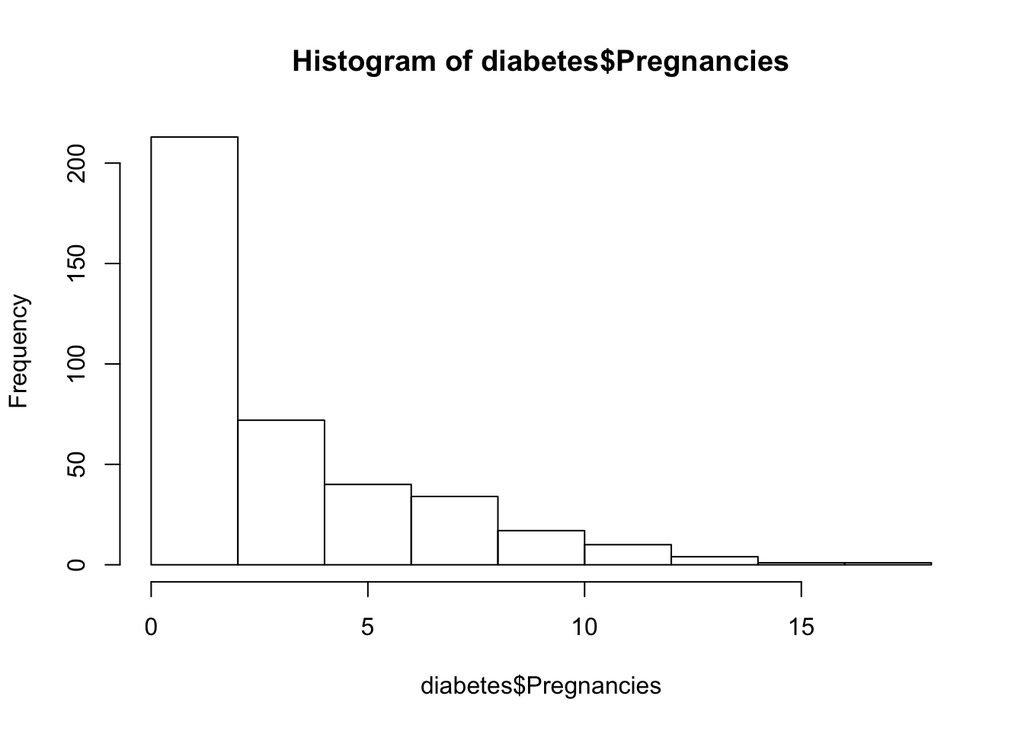

```r
# Look at histograms
hist(diabetes$Pregnancies)
```

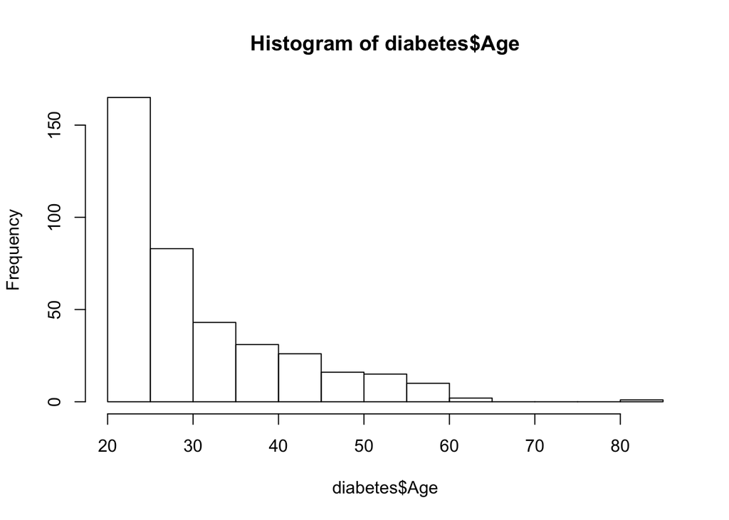

```r
hist(diabetes$Age)
```

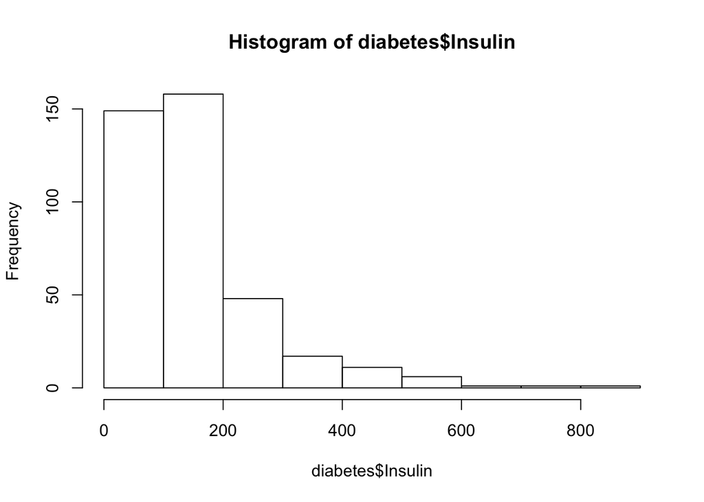

```r
hist(diabetes$Insulin)
```

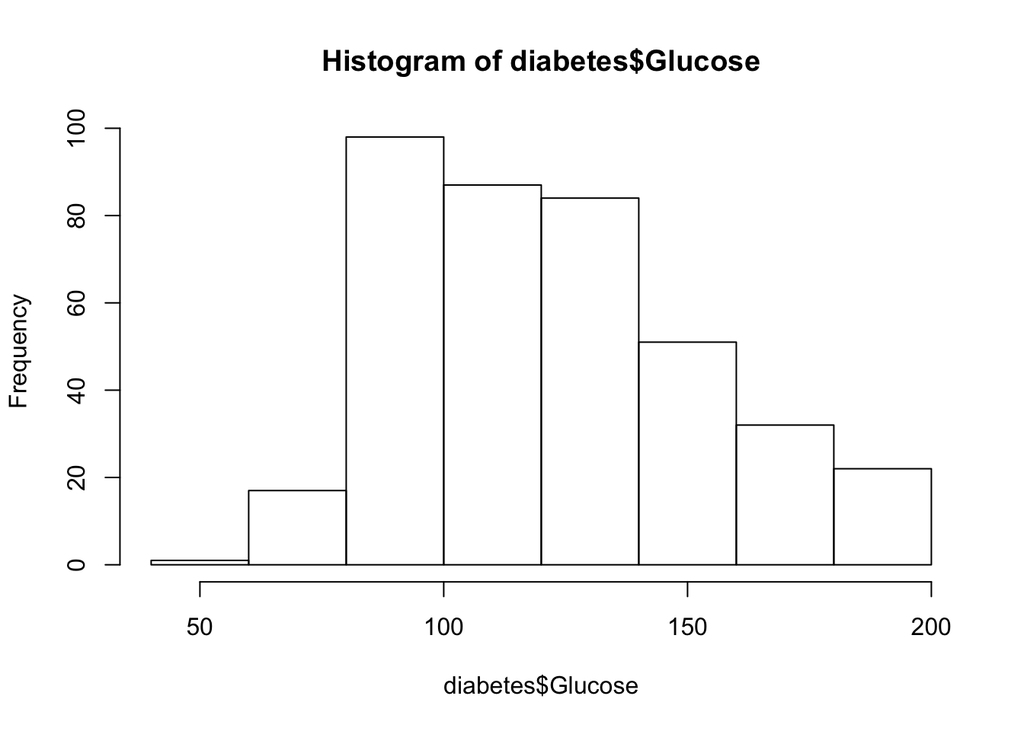

```r
hist(diabetes$Glucose)
```

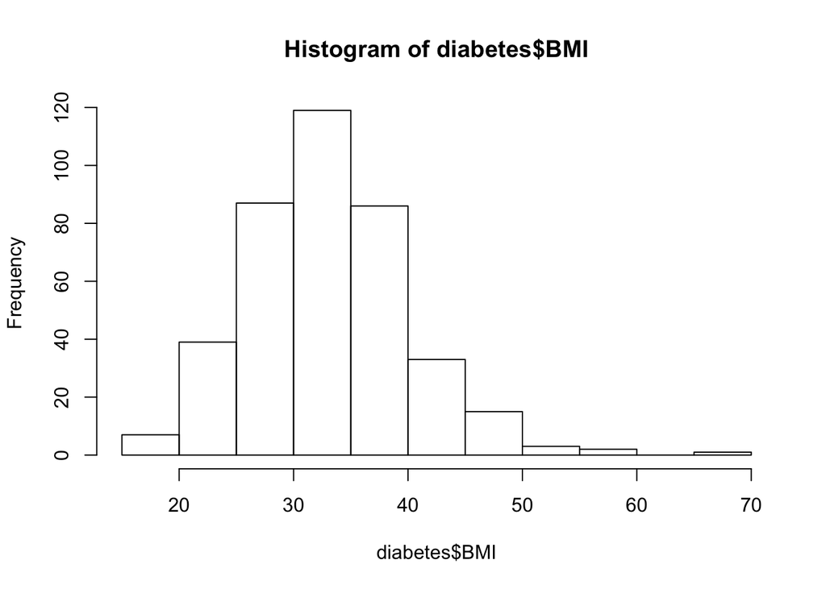

```r
hist(diabetes$BMI)
```

# Define Models

*Build a simple model for linear classification based on the “Outcome” column.*

```r
# Set seed
set.seed(1)

# Split the data into training/test sets
train <- sample(1:nrow(diabetes), nrow(diabetes)/2)
diabetes.train <- diabetes[train,]
diabetes.test <- diabetes[-train,]
```

I decided to split the training and test sets into two equal groups, in terms of sample size.

## Model #1: Logistic Regression

### Fit the Model

I am first going to fit a model using a logistic regression (GLM) method because `Outcome` is a binary response variable. I decided to use all of the variables for this first model, but I may try to remove either `Age` or `Pregnancies` and see if that improves model accuracy in a future version of this analysis.

```r
# Fit the model using training data
diabetes.glm <- glm(Outcome ~ ., data = diabetes, family = "binomial",
                    subset = train)

# Look at summary
summary(diabetes.glm)
```

```
##
## Call:
## glm(formula = Outcome ~ ., family = "binomial", data = diabetes,
##     subset = train)
##
## Deviance Residuals:
##     Min       1Q   Median       3Q      Max
## -2.3955  -0.6607  -0.3202   0.5517   2.3666
##
## Coefficients:
##                            Estimate Std. Error z value Pr(>|z|)
## (Intercept)              -11.422792   1.949922  -5.858 4.68e-09 ***
## Pregnancies                0.057684   0.077746   0.742    0.458
## Glucose                    0.047210   0.008923   5.291 1.22e-07 ***
## BloodPressure              0.005530   0.020177   0.274    0.784
## SkinThickness              0.013606   0.025965   0.524    0.600
## Insulin                   -0.003039   0.001831  -1.660    0.097 .
## BMI                        0.075062   0.044679   1.680    0.093 .
## DiabetesPedigreeFunction   0.350197   0.558886   0.627    0.531
## Age                        0.036353   0.025543   1.423    0.155
## ---
## Signif. codes:  0 '***' 0.001 '**' 0.01 '*' 0.05 '.' 0.1 ' ' 1
##
## (Dispersion parameter for binomial family taken to be 1)
##
##     Null deviance: 239.80  on 195  degrees of freedom
## Residual deviance: 161.23  on 187  degrees of freedom
## AIC: 179.23
##
## Number of Fisher Scoring iterations: 5
```

### Evaluate Model

```r
# Predict the new model using the validation set
diabetes.pr <- predict(diabetes.glm, newdata = diabetes.test,
                           type = "response")

# Assign predicted responses to 0
diabetes.glm.pr <- rep(0, length(diabetes.pr))

# Assign 1 to predicted responses if the posterior probability is >= 0.5
diabetes.glm.pr[diabetes.pr >= 0.5] <- 1

# Compute the validation set error
glm.testerror <- mean(diabetes.glm.pr != diabetes.test$Outcome) * 100
glm.testerror
```

```
## [1] 23.97959
```

Using the validation set approach, we have a **23.9795918%** test error rate.

```r
# Calculate accuracy of model
correct_predictions <- sum(table(diabetes.glm.pr, diabetes$Outcome[-train])[c(1, 4)])
total <- length(diabetes$Outcome[-train])
accuracy.glm <- (correct_predictions / total) * 100
accuracy.glm
```

```
## [1] 76.02041
```

The accuracy of the model using a logistic regression model is **76.0204082%**.

## Model #2: Lasso

### Fit the Model

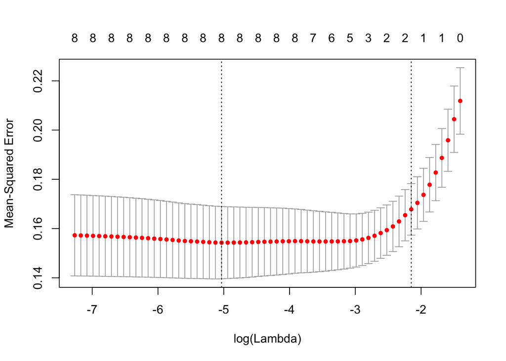

```r
# Prepare for cv.glmnet
x <- model.matrix(Outcome ~ . - 1, data = diabetes) # remove outcome variable with -1
y <- diabetes$Outcome

# Use cross-validation to select lambda
lasso.cv <- cv.glmnet(x[train, ], y[train], alpha = 1)

# Create plot
plot(lasso.cv)
```

The plot shows the cross-validation curve (the red-dotted line), and the upper and lower standard deviation curves along the sequence of log(Lambda) values which are across the X-axis. Mean-squared error (CV error) is on the Y-axis. The selected lambda values are shown through the vertical dotted lines. The values (not log versions) are: 0.0065172 and 0.1165702.

### Evaluate Model

```r
# Refit the model using lambda.min
lasso.refit <- glmnet(x[train, ], y[train], alpha = 1, lambda = lasso.cv$lambda.min)
coef(lasso.refit)[,1]
```

```
##              (Intercept)              Pregnancies                  Glucose
##            -1.1423121543             0.0085107474             0.0071588456
##            BloodPressure            SkinThickness                  Insulin
##             0.0008578604             0.0011594790            -0.0003266257
##                      BMI DiabetesPedigreeFunction                      Age
##             0.0084318912             0.0639313118             0.0054547755
```

When using the lambda that gives the minimum cross-validation error (found in `lasso.cv`), no variables are shrunk to 0.

```r
# Predict using the test set & the refit model that uses lambda.min
lasso.cv.pr <- predict(lasso.refit, newx = x[-train, ])

# Assign predicted responses to 0 & assign 1 to predicted responses if the posterior probability is >= 0.5
lasso.cv.pr <- ifelse(lasso.cv.pr >= 0.5, 1, 0)

# Confusion Matrix
table(lasso.cv.pr, y[-train])
```

```
##
## lasso.cv.pr   0   1
##           0 117  36
##           1   8  35
```

```r
# Compute the validation (test) set error
lasso.cv.pr.error <- mean(lasso.cv.pr != y[-train]) * 100
lasso.cv.pr.error
```

```
## [1] 22.44898
```

Using the validation set approach, we have a **22.4489796%** test error rate.

```r
# Calculate accuracy of model
correct_predictions <- sum(table(lasso.cv.pr, y[-train])[c(1, 4)])
total <- length(y[-train])
accuracy.lasso <- (correct_predictions / total) * 100
accuracy.lasso
```

```
## [1] 77.55102
```

The accuracy of the model using Lasso is **77.5510204%**.